# Análise da Geração, Consumo e Consumidores

# Diferenças Regionais no Consumo

O Brasil é um país com grande variedade regional, e isso se reflete nos padrões de consumo de energia elétrica. Cada região possui suas próprias características econômicas, sociais e geográficas que influenciam diretamente a demanda por eletricidade. Ao longo das últimas duas décadas, o país como um todo experimentou um crescimento consistente no consumo energético, impulsionado pelo desenvolvimento econômico, expansão da infraestrutura e aumento populacional. No entanto, as oscilações no consumo são evidentes em certos períodos, especialmente em 2020, quando os efeitos da pandemia de COVID-19 impactaram fortemente a atividade econômica e, consequentemente, o consumo de energia. As regiões apresentam padrões distintos de consumo, com crescimento mais acentuado em algumas áreas, refletindo mudanças no desenvolvimento e industrialização.

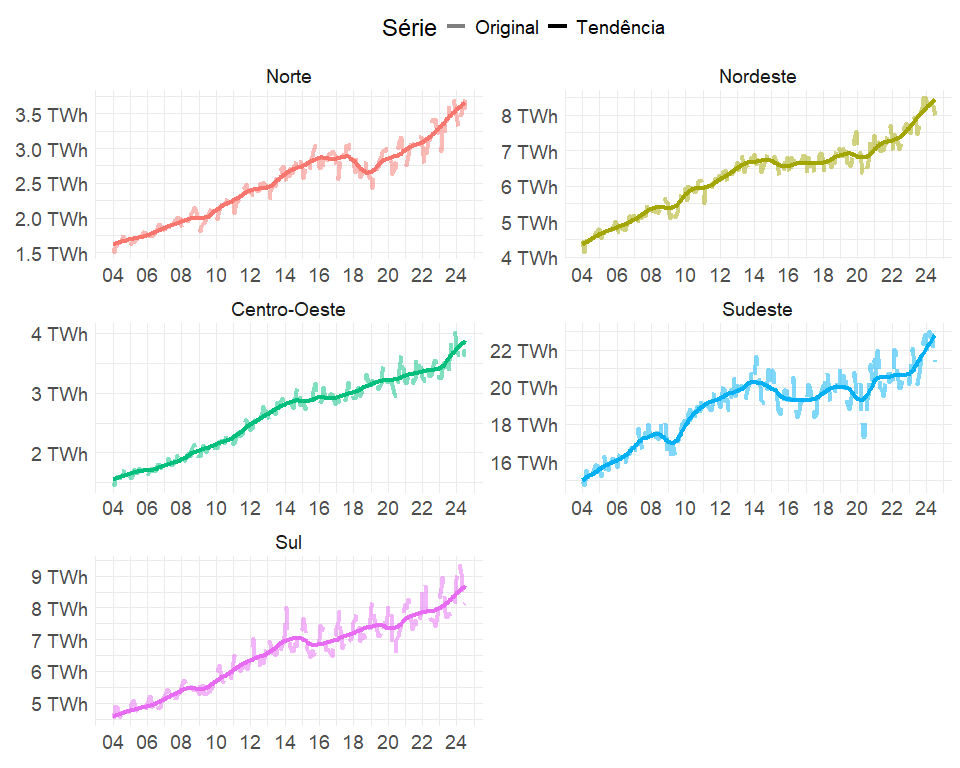

```r
### Consumo Regionais ####
consumo %>%
  dplyr::summarise(Consumo = sum(Consumo),
                   .by = c(DataExcel, Regiao)) %>%
  dplyr::mutate(DataExcel = tsibble::yearmonth(DataExcel)) %>%
  tsibble::as_tsibble(index = DataExcel, key = Regiao) %>%
  fabletools::model(STL(Consumo)) %>%
  fabletools::components() %>%
  dplyr::mutate(DataExcel = as.Date(DataExcel),
                Regiao = factor(Regiao,
                                     levels = c("Norte",
                                                "Nordeste",
                                                "Centro-Oeste",
                                                "Sudeste",
                                                "Sul"))) %>%
  ggplot() +
  geom_line(aes(x = DataExcel,
                y = Consumo,
                color = Regiao,
                linetype = 'Original'),
            linewidth = 1.45,
            alpha = 0.5) +
  geom_line(aes(x = DataExcel,
                y = trend,
                color = Regiao,
                linetype = 'Tendência'),
            linewidth = 1.45) +
  labs(x = element_blank(),
       y = element_blank(),
       linetype = 'Série',
       color = 'Região') +
  scale_x_date(date_breaks = '2 year',
               date_labels = '%y') +
  scale_y_continuous(labels = scales::number_format(suffix = ' TWh',
                                                    scale = 1/1e6)) +
  scale_linetype_manual(values = c('longdash', 'solid')) +
  facet_wrap(~Regiao, scales = 'free', ncol = 2) +
  theme_minimal() +
  theme(text = element_text(size = 18),
        legend.position = 'top') +
  guides(color = "none")
```